# Part_II_slide_deck - [Fordgobike-trip]

## by Oluwadamilare Shiji

## Investigation Overview

> The investigation of this dataset was conducted using the Python libraries pandas, Matplotlib, seaborn, and numpy. This was conducted to look into biker characteristics that could be useful to predict trip duration. The main focus of this dataset the following variables which are `start_time`, `duration_sec`, `age`, `gender`, `user_type`.

## Dataset Overview

> A bike sharing program called GoBike was launched in the San Francisco Bay Area in 2017. The dataset was analysed and cleaned for the month of February 2019 and had 14 characteristics and 183,412 observations. The dataset can be found here. [GoBike](https://www.lyft.com/bikes/bay-wheels/system-data)

## Bike User Distribution

> From the total entry of 183,412 observations in february 2019 data, it shows that more than four-fifths of bike users are Subscribers.  
> Customer : 16566  
> Subcriber : 158386

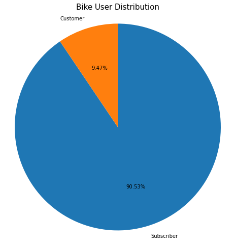

## Time Usage Analyses

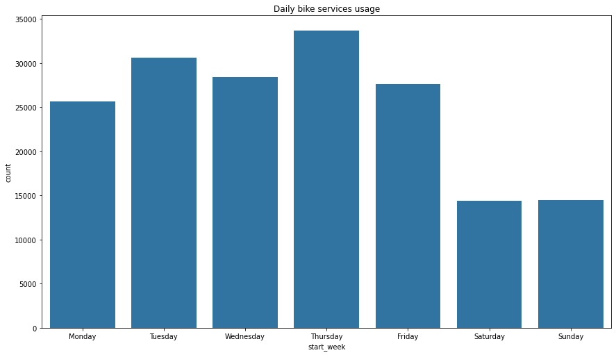

> Most bike users make use of the bike services on Thursdays

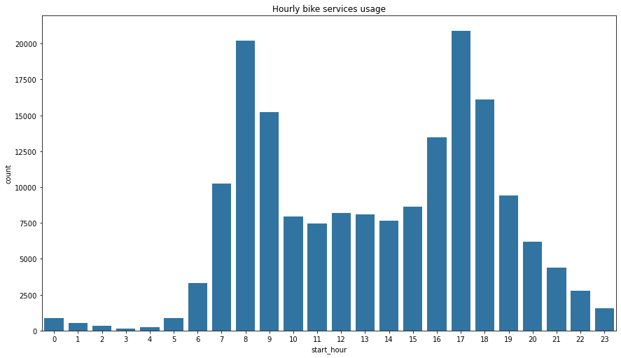

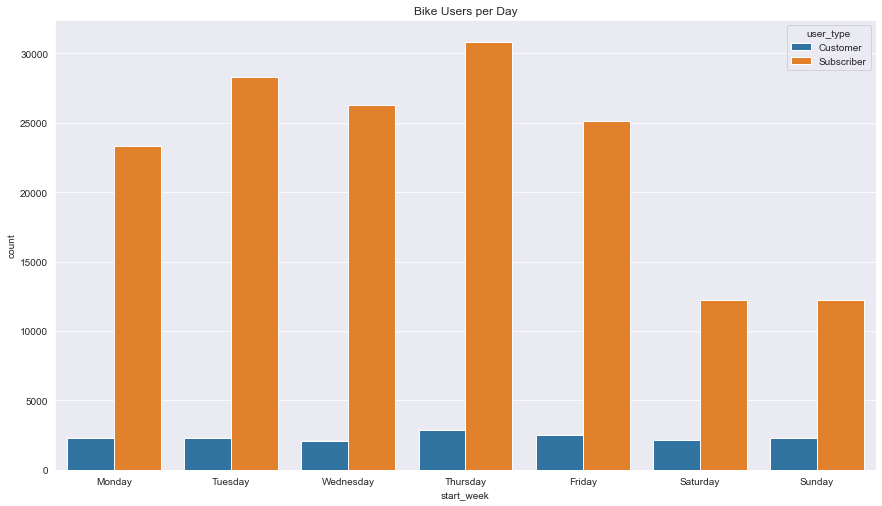

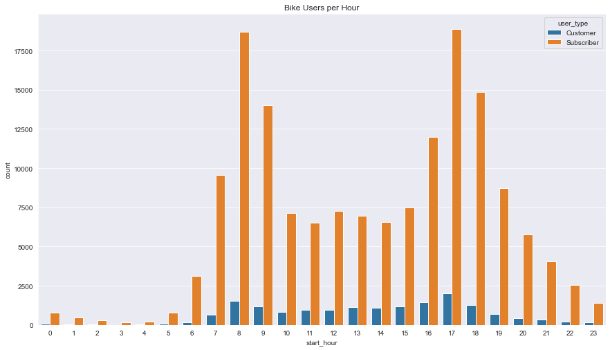

> From the plot, it is shown that this is a bimodal plot. It also shows that there are 2 peak periods daily which are 8AM and 5PM. The reason for this is that by 8AM most customers and subscribers go to their various work places, schools, execrises and so on. Same as 5PM, most users are returning from schools, offices etc.

## Duration Trip Analyses

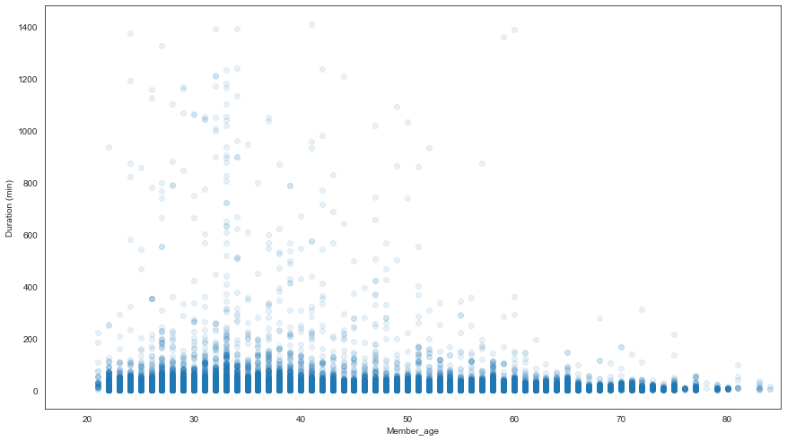

> This shows that most users between ages 32 - 34 years ride the longest trips. While users above 70 years ride te shortest trips.

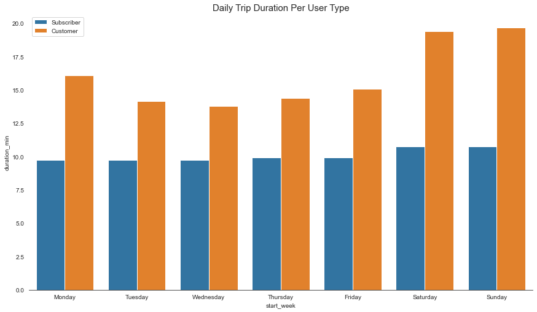

> From the plot above, it shows that both subscriber and customer user type spend more time on the trip duration during the weekends than the weekdays. This is because, most users do not go to their various offices and schools during the weekend. They tend to spend more time on running errands, exercises an so on.